# LendingClub Peer-to-Peer Loan Analysis

Team 1: Jonathan Schild, Medhasweta Sen, Brian Gulko, Bharat Premnath | The George Washington University

2022-12-15

# 1 Introduction

Peer-to-peer (P2P) lending was a phenomenon less than ten years ago, exploding in popularity by offering a break from traditional banking. Individuals flocked to these alternative credit markets to finance their small business ventures, home purchases, and to consolidate debt. Although direct P2P lending has undergone changes over recent years, it remains a viable option for borrowers and investors.

The global P2P lending market is anticipated to grow from $84 billion in 2021 to $706 billion by 2030, according to figures from Precedence Research.[^1] This analysis takes a closer look at the mechanics of P2P lending to gain a better understanding of what considerations are factored into decisions to apply for, issue, and provide financing via P2P platforms. Analysis and statistical testing identifies credit underwriting policy and borrowers’ failure to fully pay as variables of interest that should be considered in future in-depth analyses.

## 1.1 What is P2P Lending?

P2P lending is the provision of financing without a traditional bank as the source of funds; it is, like it sounds, peers lending money to their peers. Instead of banks, online lending platforms provide a service that connects willing lenders, or investors, with individuals seeking to borrow funds. Historically, these investors have been predominantly private individuals seeking alternate forms of investments, wherein they receive the interest earned on the money they loan out.

[figure not shown]

Borrowers, on the other hand, are connected to feasible funding that they might not have otherwise been able to attain. Many borrowers participating in P2P lending did or would have experienced difficulties qualifying for traditional loans from banks. This perception of higher risk among the lenders can often translate into higher interest rates. P2P platforms screen borrowers and set rates and terms but it is ultimately up to the lender whether they will provide the funds.

## 1.2 LendingClub

The P2P market was dominated by LendingClub during the early rise of P2P lending, and it remains a leader in the industry. It makes money by charging borrowers an origination fee, charging investors a service fee, and selling loans in secondary markets. LendingClub’s typical annual percentage rate (APR) is between 5.99% and 35.89% while the origination fee of 1% to 6% is taken off the top of loans. Borrowers on LendingClub typically have good-to-excellent credit (700 or higher credit score) and a low debt-to-income ratio.

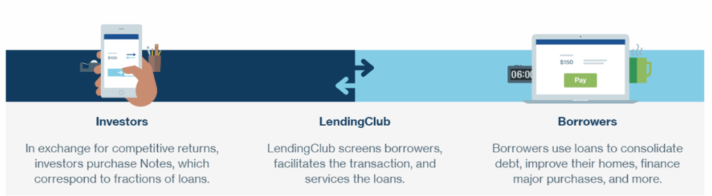

## 1.3 Our Data

Our dataset contains over 9,500 observations of loan data from LendingClub from between 2007 and 2015. We obtained the dataset from Kaggle here: https://www.kaggle.com/datasets/urstrulyvikas/lending-club-loan-data-analysis

Our work is stored on our team GitHub here: https://github.com/jschild01/JMB_DATS_6101

Below are the variables in the dataset and their accompanying definitions as supplied by Kaggle:

| Variable | Definition |
| --- | --- |
| credit.policy | 1 if the customer meets the credit underwriting criteria of LendingClub.com, and 0 otherwise. |
| purpose | The purpose of the loan (takes values creditcard, debtconsolidation, educational, majorpurchase, smallbusiness, and all_other). |
| int.rate | The interest rate of the loan, as a proportion (a rate of 11% would be stored as 0.11). Borrowers judged by LendingClub.com to be more risky are assigned higher interest rates. |
| installment | The monthly installments owed by the borrower if the loan is funded. |
| log.annual.inc | The natural log of the self-reported annual income of the borrower. |
| dti | The debt-to-income ratio of the borrower (amount of debt divided by annual income). |
| fico | The FICO credit score of the borrower. |
| days.with.cr.line | The number of days the borrower has had a credit line. |
| revol.bal | The borrower’s revolving balance (amount unpaid at the end of the credit card billing cycle). |
| revol.util | The borrower’s revolving line utilization rate (the amount of the credit line used relative to total credit available). |
| inq.last.6mths | The borrower’s number of inquiries by creditors in the last 6 months. |
| delinq.2yrs | The number of times the borrower had been 30+ days past due on a payment in the past 2 years. |
| pub.rec | The borrower’s number of derogatory public records (bankruptcy filings, tax liens, or judgments). |
| not.fully.paid | Whether the borrower will be fully paid or not. |

## 1.4 SMART Questions

Our analysis will explore things such as income-to-debt ratios, credit score, interest rates, and delinquencies among direct P2P borrowers in an attempt to understand the risks and opportunities associated with P2P lending. Specifically, we intend to examine the impact that these variables have on who received loans and who defaulted on their loans between 2007 and 2015.

We will seek to answer the following questions:

1. What variable or variables, if any, have an impact on if the person meets the credit underwriting criteria?
2. What variable or variables, if any, have an impact on if the person fully repays the loan?
3. Do borrowers who meet the credit underwriting criteria have a lower chance of not fully repaying the loan? If so, how big is the difference?

# 2 EDA Review and Follow-up

Our exploratory data analysis followed the below 9-step checklist presented in Chapter 4 of *The Art of Data Science*.[^2]

1. Formulate our question
2. Read in our data
3. Check the packaging
4. Look at the top and the bottom of your data
5. Check your “n”s
6. Validate with at least one external data source
7. Make a plot
8. Try the easy solution first
9. Follow up

Since our dataset is a subset of all loans facilitated by LendingClub between the years 2007 and 2015, we treated it as a sample and conducted t-tests which confirmed that the means of all the variables of the sample coincide with the means of our population. However, we could not perform z-tests on this data because we could not make an estimate about the standard deviation of the population (all loans facilitated by LendingClub).[^3] [^4] [^5] [^6] [^7]

In summary, our EDA found:

1. The credit underwriting criteria of LendingClub is proven to be effective as borrowers who do not meet the credit underwriting criteria are more than twice as likely to default in comparison to borrowers who do meet the criteria.
2. There are some proven relationships between `credit.policy` and other numeric variables such as `int.rate`, `fico`, and `inq.last.6mths`. Additionally, there was no clearly established relationships between `not.fully.paid` and other numeric variables (except for `credit.policy`).
3. There are statistically significant relationships between the categorical and logical variables `purpose`, `credit.policy`, and `not.fully.paid`.
4. For all numeric variables except for `delinq.2yrs`, their mean significantly varies for different categories of`purpose`.

Before we get into making models, there is some work we would like to do with the dataset first.

## 2.1 Converting Variables

From our EDA we know that the `credit.policy` and `not.fully.paid` variables function as logicals, and the `purpose` variable functions as a factor with 7 levels. We will start by formally converting these variables from numerical data-types in R to logical and the factor data-types, respectively.

Of the 14 variables in the original dataset, 11 are numeric, 2 are logical, and 1 is a factor.

## 2.2 Adding Additional Logicals

From our EDA we saw that the overwhelming majority of loans had a value of 0 for `delinq.2yrs` and `pub.rec`. The variables might be more useful in terms of having stronger correlations and a larger impact in models if we create logical versions of these variables. We will introduce `has.delinq.2yrs` and `has.pub.rec` based on whether or not the value is 0 or greater than 0.

## 2.3 Revolving Balance Transformation

From our EDA we saw that the `revol.bal` variable had a wide range of values as well as outlier issues. We wondered if it would work better if we took the natural log of it, similar to how the income provided in the dataset (the `log.annual.inc` variable) is in the form of the natural log. However, some values for `revol.bal` are 0, and taking the natural log of that results in -Inf. One way to deal with this without removing those values is to add 1 to all of the values for `revol.bal` before taking the natural log.

## 2.4 Utility of the new variables

Now that we have added some new variables, it would be helpful to look at a correlation plot and make some comparisons to assess whether they would be more useful going forward than their original forms.

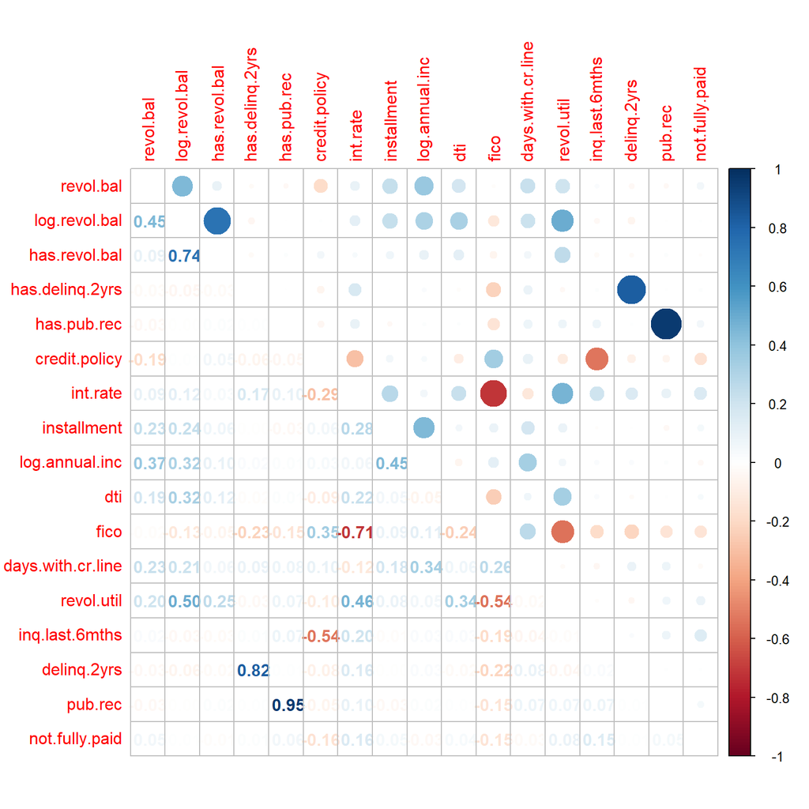

Some notable observations of this:

1. `has.delinq.2yrs` doesn’t have any strong correlations, and the 2 potentially useful ones (`int.rate` and `fico`) are almost exactly the same as `delinq.2yrs`.
2. Similarly, `has.pub.rec` doesn’t have any strong correlations, and the 2 potentially useful ones (`int.rate` and `fico`) are the same as `pub.rec`.
3. `log.revol.bal` has a stronger correlation with `dti` and a much stronger correlation with `revol.util` compared to `revol.bal`.
4. `log.revol.bal` has a weaker correlation with `credit.policy` compared to `revol.bal`.
5. `has.revol.bal` does not have a significant correlation with anything (`log.revol.bal` excepted) except `revol.util`, where the correlation is weaker than that of `log.revol.bal`.

From this we can conclude that converting `delinq.2yrs` and `pub.rec` to logicals did not add any advantage for our dataset. We can also conclude that the `has.revol.bal` variable is not necessary and will not add value to our analysis beyond what `log.revol.bal` already covers. Successfully eliminating these as possibilities increases our confidence in the use of their original structures.

Lastly, we see that taking the natural log of `revol.bal` might be useful, as `log.revol.bal` has some stronger correlations than `revol.bal`. We will note this as we proceed with our modeling.

## 2.5 Updated Visuals

Now that we have our final dataset, let’s rerun some of the EDA graphs before we move onto modeling. These are updated histograms, boxplots, Q-Q plots, and barplots with the added variables.

### 2.5.1 Histograms

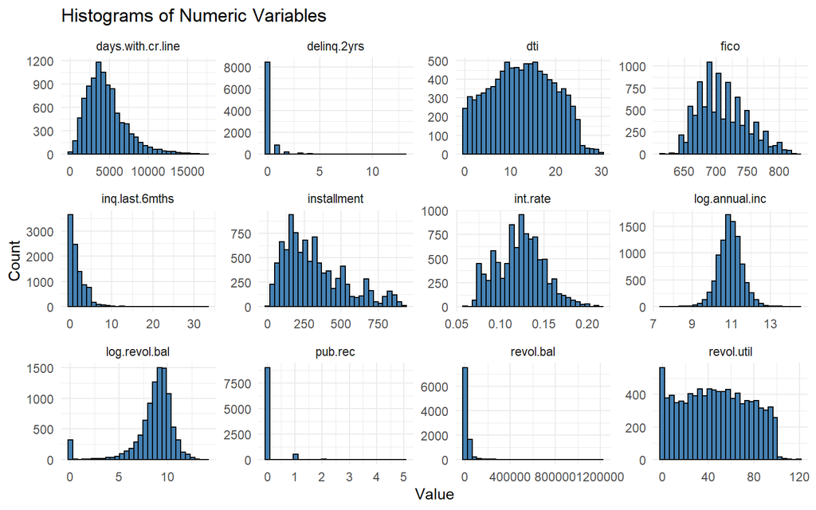

### 2.5.2 Boxplots

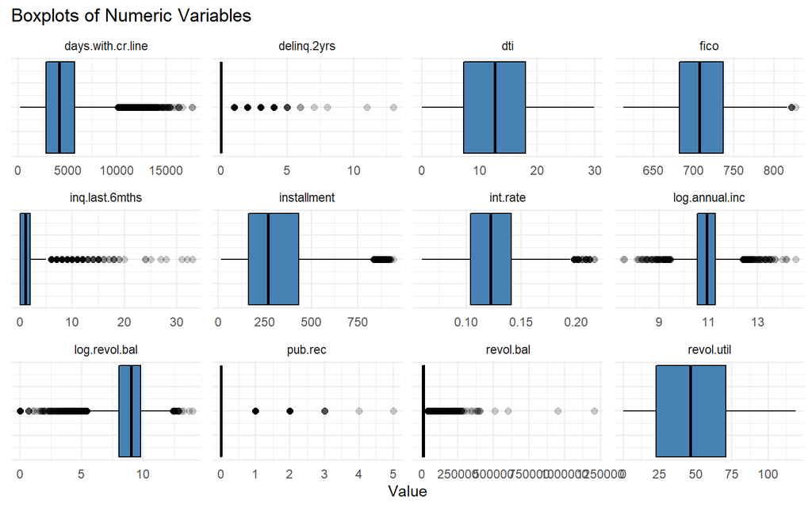

### 2.5.3 Q-Q Plots

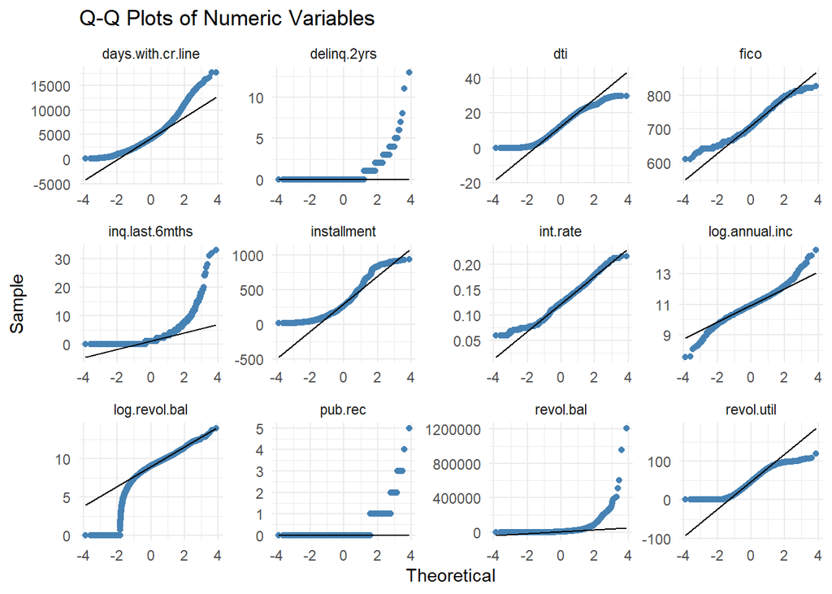

### 2.5.4 Bar Plots

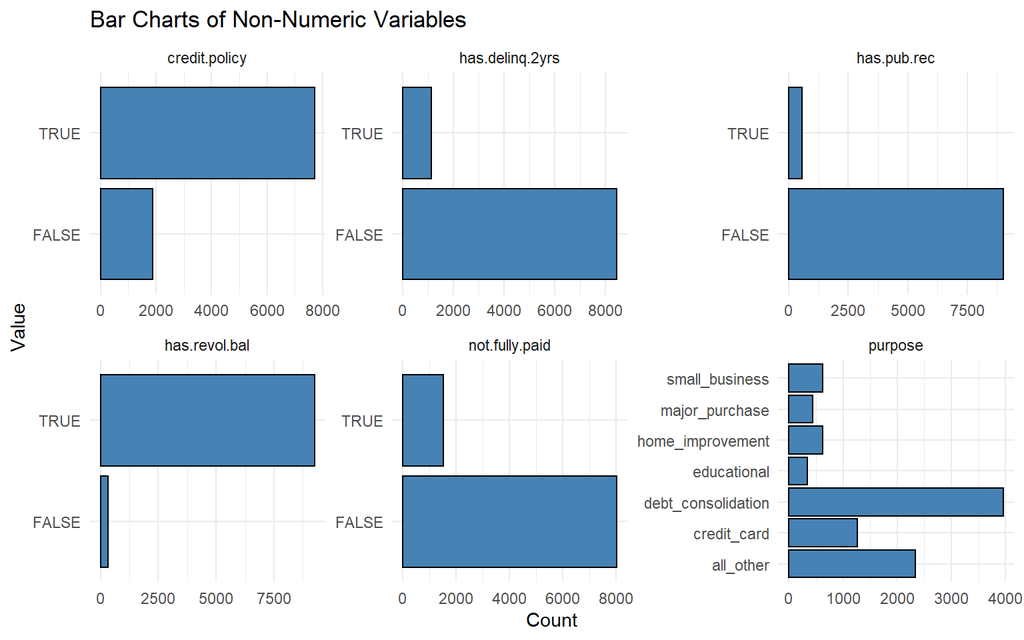

# 3 Choosing Our Models

To better understand our data and attempt to answer our SMART questions, we decided to use the following models:

- 5 Simple Linear Regressions
- 3 Multiple Regressions
- 1 LASSO Regression
- 2 Logistic Regressions
- 2 Classification Trees

# 4 Simple Linear Regression

From the correlation plot we see 5 combinations of variables with notable correlations (greater than 0.4 or less than -0.4) that we would like to explore further by trying to model them with simple linear regressions.

## 4.1 Interest Rate vs FICO Score

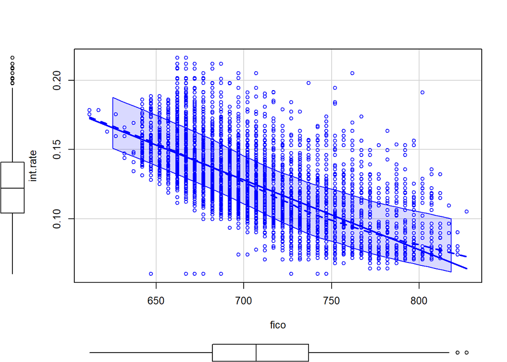

## 4.2 Revolving Utilization Rate vs Interest Rate

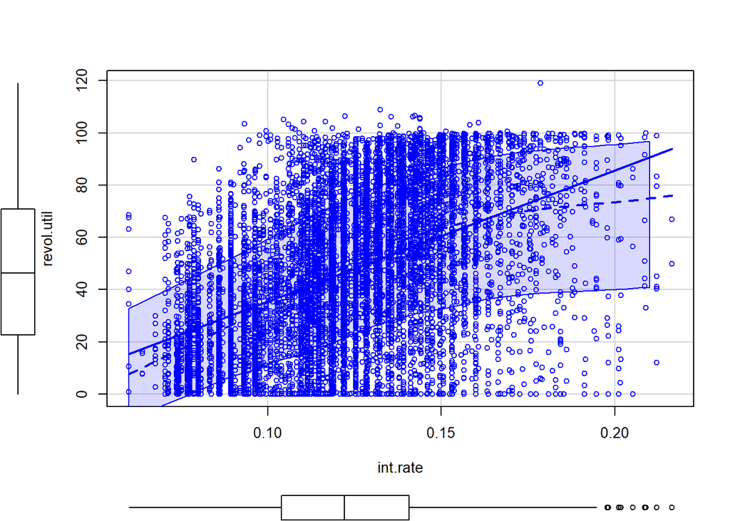

## 4.3 Installment vs Natural Log of Annual Income

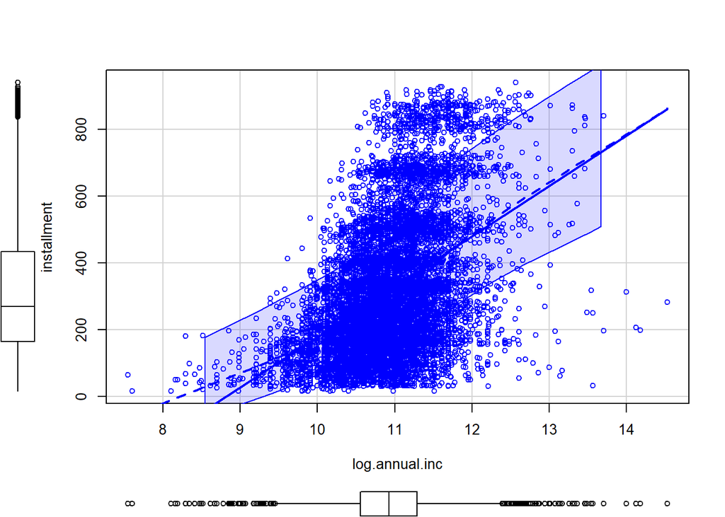

## 4.4 Revolving Utilization Rate vs FICO Score

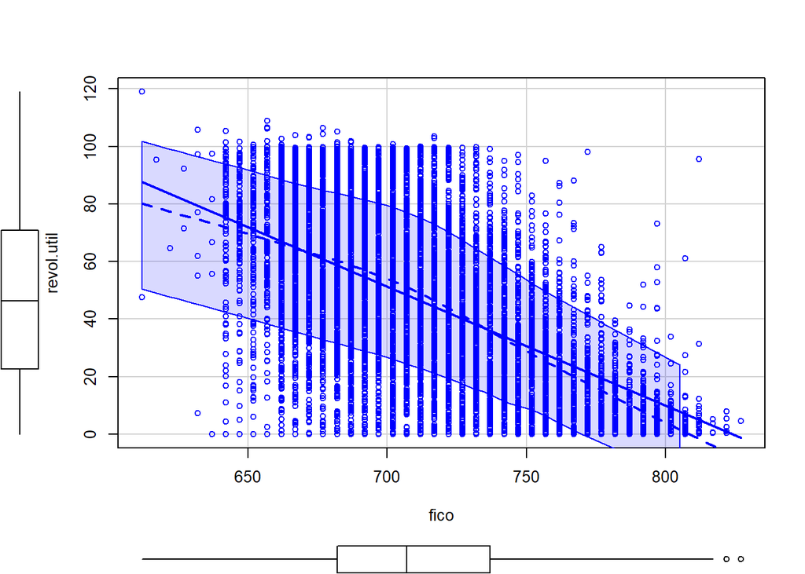

## 4.5 Revolving Utilization Rate vs Natural Log of Revolving Balance

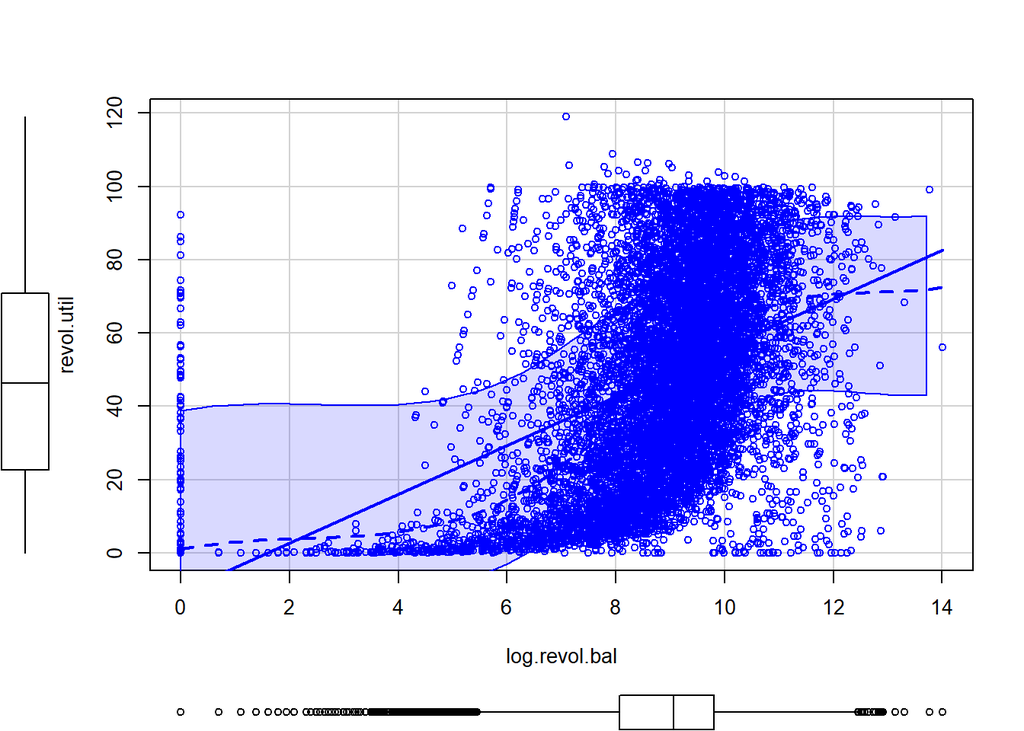

## 4.6 Evaluation of Models

1. The first one is interest rate vs FICO score. We can see from the graph that the relation is almost linear as the linear regression line lies close to the true regression line. This is further confirmed by the adjusted r^2 value that is relatively significant at 51% and the p value at least than 0.05.
2. The second one is revolving utilization rate vs interest rate. We can see from the graph that the relation is not as linear as the linear regression line lies tangent to the true regression line. This is further confirmed by the adjusted r^2 value that is relatively low at 21% and the p value at least than 0.05.
3. The third one is installment vs natural log of annual income. We can see from the graph that the relation is not as linear as the linear regression line lies tangent to the true regression line but converges as both variables increase. This is further confirmed by the adjusted r^2 value that is relatively low at 20% and the p value at least than 0.05.
4. The fourth one is revolving utilization rate vs FICO score. We can see from the graph that the relation is not as linear as the linear regression line lies relatively loser to the true regression line in comparison to the previous two cases. This is further confirmed by the adjusted r^2 value that is relatively low at 29% and the p value at least than 0.05.
5. The fifth one is revolving utilization rate vs natural log of revolving balance. We can see that the true regression is far from linear the adjusted r^2 is relatively low at 24.85%.

Overall we can conclude that simple linear regression is not an effective way to model these relationships, though the first model isn’t too bad.

Since, none of the variables are quite linearly related this should mean multicolinearity shouldn’t be a problem here while we build our MLR.

# 5 Multiple Linear Regression for Interest Rate

Since we know that interest rate is higher for riskier loans we wanted to test that by building a model to predict interest rate.

## 5.1 Feature Selection

This helps us to rank the independent variables in the descending order of their importance and helps us pick the ones that we relevant in deciding the rate of interest for a loan. It is to be noted that variables like revolving balance and revolving utility isn’t available at the time of deciding the rate of interest these cannot be used in the model.

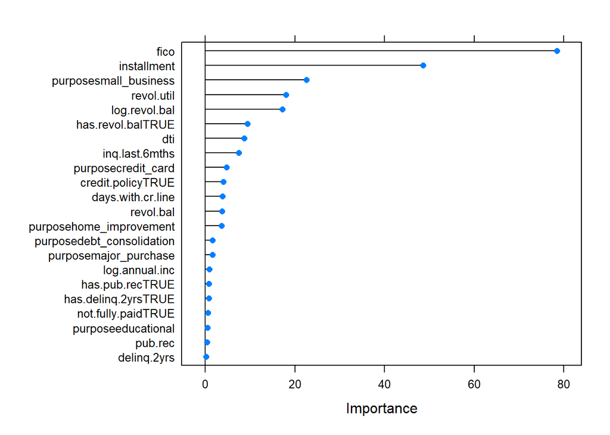

## 5.2 Multiple Linear Regression Model

```
##               (Intercept)                      fico               installment
##              0.4819228196             -0.0005143307              0.0000428540
##        purposecredit_card purposedebt_consolidation        purposeeducational
##             -0.0033260863             -0.0012546309              0.0001820383
##   purposehome_improvement     purposemajor_purchase     purposesmall_business
##              0.0019883173              0.0014739586              0.0157732687
##                       dti            inq.last.6mths         credit.policyTRUE
##              0.0001682692              0.0005470733             -0.0020864159
##            log.annual.inc
##             -0.0008158434
```

```
##                                   2.5 %        97.5 %
## (Intercept)                4.731186e-01  4.907271e-01
## fico                      -5.236009e-04 -5.050605e-04
## installment                4.107866e-05  4.462934e-05
## purposecredit_card        -4.423902e-03 -2.228270e-03
## purposedebt_consolidation -2.099536e-03 -4.097257e-04
## purposeeducational        -1.609548e-03  1.973625e-03
## purposehome_improvement    5.855629e-04  3.391072e-03
## purposemajor_purchase     -1.358131e-04  3.083730e-03
## purposesmall_business      1.434543e-02  1.720111e-02
## dti                        1.199051e-04  2.166333e-04
## inq.last.6mths             3.765454e-04  7.176012e-04
## credit.policyTRUE         -3.076261e-03 -1.096571e-03
## log.annual.inc            -1.402356e-03 -2.293305e-04
```

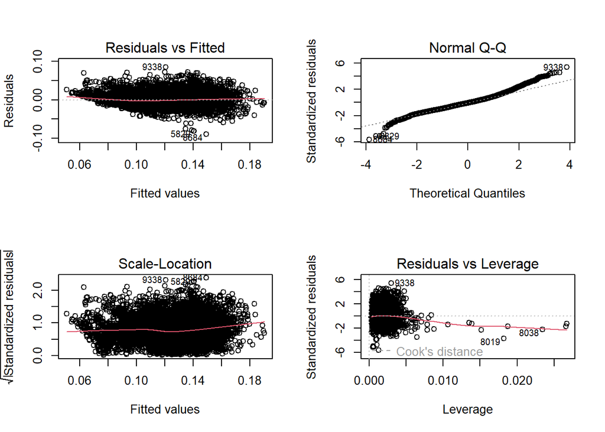

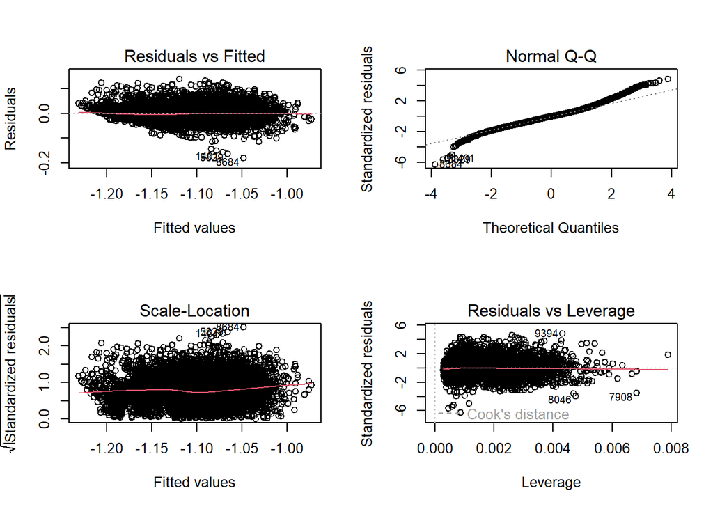

# 6 LASSO Regression for Interest Rate

We decided to try LASSO regression as lasso performs better in the presence of outliers and avoids overfitting, and eliminates less important features thereby helping in interpreting the model better.

[output not shown]

[output not shown]

The entire data regressor and response data was split in to 70% and 30% for training and testing purpose.

To run the LASSO Regression the library glmnet was used and the solver cv.glmnet was used.

The below shows the shrunk coefficients obtained from the model. The unimportant coefficients go to zero. The dots next to the coefficient names represent the shrinkage of the unimportant variables to zero.

```
## 20 x 1 sparse Matrix of class "dgCMatrix"
##                              s1
## (Intercept)        4.464100e-01
## installment        3.727407e-05
## log.annual.inc     .
## dti                .
## fico              -4.718489e-04
## days.with.cr.line  .
## revol.bal          .
## inq.last.6mths     2.789728e-04
## delinq.2yrs        .
## pub.rec            .
## credit.policy.T   -8.322713e-04
## credit.policy.F    4.885155e-16
## has.delinq.2yrs.T  .
## has.delinq.2yrs.F  .
## has.revol.bal.T    .
## has.revol.bal.F    .
## has.pub.rec.T      .
## has.pub.rec.F      .
## not.fully.paid.T   .
## not.fully.paid.F   .
```

The obtained model is used to predict the interest rate using the reserved 30% testing data and the Mean Squared Error (MSE) & R-squared value are tabulated below.

The MSE:

```
## [1] 0.0002514385
```

The R-squared value:

```
## [1] 0.6470912
```

The below graph shows the Importance of variables to predict the interest rates. To interpret in common language, these predictors play major role in deciding the interest rates for the customers.

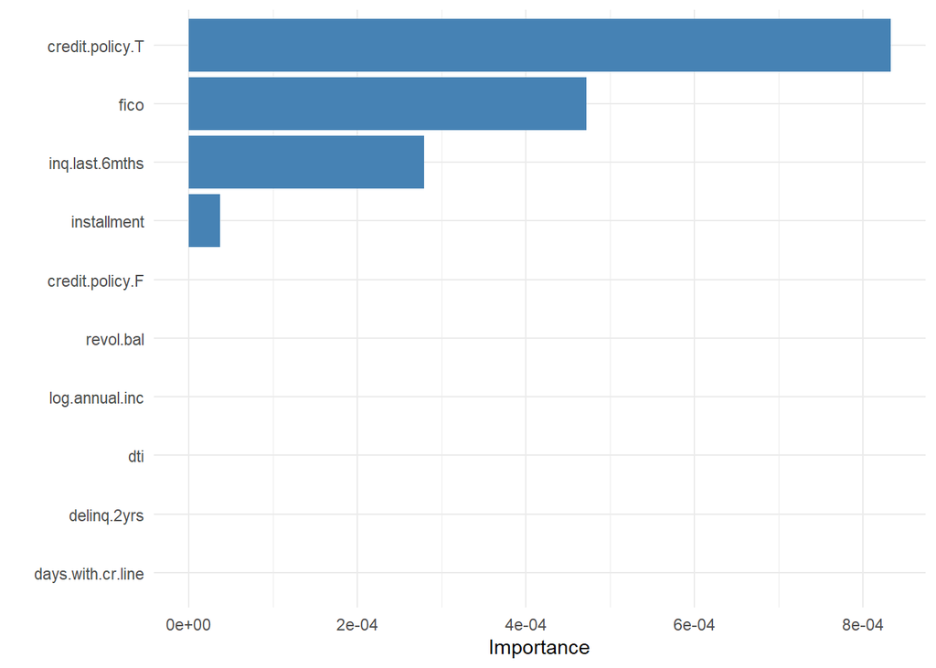

It is clear from the graph that the interest rates are heavily influenced by the compliance with the credit policy and credit score (fico).

# 7 Logistic Regression for Credit Policy

## 7.1 Effects on Credit Policy by Purpose

To study the effects on `credit.policy` by the factor `purpose` (`credit.policy` and `purpose` are both categorical variables), we can create two-way contingency table of the outcome and predictors, and make sure there are no cells of zero frequencies.

|  | all_other | credit_card | debt_consolidation | educational | home_improvement | major_purchase | small_business |
| --- | --- | --- | --- | --- | --- | --- | --- |
| FALSE | 496 | 242 | 734 | 89 | 117 | 66 | 124 |
| TRUE | 1835 | 1020 | 3223 | 254 | 512 | 371 | 495 |

## 7.2 Feature Selection

This helps us to rank the independent variables in the descending order of their importance and helps us pick the ones that we relevant in deciding the credit underwriting criteria for a loan. It is to be noted that variables like revolving balance and revolving utility isn’t available at the time of deciding the credit policy these cannot be used in the model.

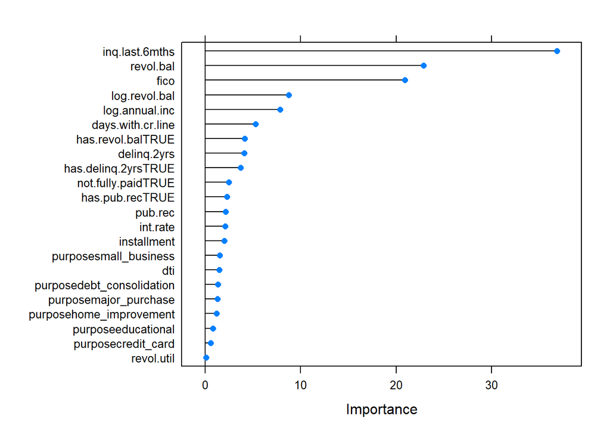

## 7.3 Logistic Regression Model

We can see the summary of the logit model here:

Logistic Regression :

|  | Estimate | Std. Error | z value | Pr(>\|z\|) |
| --- | --- | --- | --- | --- |
| (Intercept) | -23.2914 | 1.0717 | -21.7330 | 0.0000 |
| inq.last.6mths | -0.8452 | 0.0223 | -37.8305 | 0.0000 |
| fico | 0.0357 | 0.0013 | 26.7228 | 0.0000 |
| log.annual.inc | 0.1406 | 0.0578 | 2.4337 | 0.0149 |
| dti | -0.0205 | 0.0053 | -3.8755 | 0.0001 |
| delinq.2yrs | -0.0255 | 0.0555 | -0.4602 | 0.6454 |
| pub.rec | 0.2791 | 0.1265 | 2.2056 | 0.0274 |
| purposecredit_card | 0.0268 | 0.1188 | 0.2255 | 0.8216 |
| purposedebt_consolidation | 0.4081 | 0.0894 | 4.5636 | 0.0000 |
| purposeeducational | -0.0394 | 0.1848 | -0.2131 | 0.8312 |
| purposehome_improvement | 0.2858 | 0.1609 | 1.7764 | 0.0757 |
| purposemajor_purchase | 0.3689 | 0.1927 | 1.9141 | 0.0556 |
| purposesmall_business | 0.1689 | 0.1557 | 1.0847 | 0.2780 |

Before moving on, let us look at the model object `logit_credit_model` a little deeper. The fitted values can be found from `logit_credit_model$fitted.values`. And the first fitted value is 0.9904137. This is the probability of credit.policyted for data point #1. Compare to the value from `predict(logit_credit_model)` to be 4.6377906.

The `predict()` function gives us the logit value. You can exponentiate to get the odds ratio p/q as 103.315827. And finally, we can find p from p/q, and indeed it is confirmed to be 0.9904137.

The easier way to get that is simply use `predict(logit_credit_model, type = c("response"))[1]` = 0.9904137. The `predict()` function will also allow you to find model prediction with unseen/untrained data points where `fitted.values` do not give.

This is stored in the model as the fitted value for the probability `p` of the first data point. Since the actual data point is a 0/1 True/False value, it is not easy to directly compare them unless we use a cutoff value (default as 0.5) to convert the probability `p` to 0/1.

Now, for unseen data point, we can use the `predict()` function to find the model predicted values. But be careful of what you are getting with the `predict()` function in classification models. Let us compare the three options below. For easy comparison, let us use the same data point in the dataset as an example.

### 7.3.1 Confidence Intervals

We can easily determine the confidence intervals of each coefficient with these two slightly different ways:

CIs using profiled log-likelihood

|  | 2.5 % | 97.5 % |
| --- | --- | --- |
| (Intercept) | -25.4097 | -21.2079 |
| inq.last.6mths | -0.8895 | -0.8020 |
| fico | 0.0331 | 0.0384 |
| log.annual.inc | 0.0275 | 0.2539 |
| dti | -0.0309 | -0.0101 |
| delinq.2yrs | -0.1330 | 0.0847 |
| pub.rec | 0.0355 | 0.5317 |
| purposecredit_card | -0.2052 | 0.2606 |
| purposedebt_consolidation | 0.2326 | 0.5832 |
| purposeeducational | -0.3970 | 0.3282 |
| purposehome_improvement | -0.0260 | 0.6051 |
| purposemajor_purchase | -0.0020 | 0.7543 |
| purposesmall_business | -0.1333 | 0.4773 |

CIs using standard errors

|  | 2.5 % | 97.5 % |
| --- | --- | --- |
| (Intercept) | -25.3919 | -21.1909 |
| inq.last.6mths | -0.8890 | -0.8014 |
| fico | 0.0331 | 0.0383 |
| log.annual.inc | 0.0274 | 0.2538 |
| dti | -0.0309 | -0.0101 |
| delinq.2yrs | -0.1343 | 0.0832 |
| pub.rec | 0.0311 | 0.5271 |
| purposecredit_card | -0.2060 | 0.2596 |
| purposedebt_consolidation | 0.2328 | 0.5834 |
| purposeeducational | -0.4017 | 0.3229 |
| purposehome_improvement | -0.0295 | 0.6012 |
| purposemajor_purchase | -0.0088 | 0.7467 |
| purposesmall_business | -0.1363 | 0.4741 |

## 7.4 Model evaluation

### 7.4.1 Confusion matrix

Confusion matrix from Logit Model

|  | Predicted FALSE | Predicted TRUE | Total |
| --- | --- | --- | --- |
| Actual FALSE | 1099 | 769 | 1868 |
| Actual TRUE | 221 | 7489 | 7710 |
| Total | 1320 | 8258 | 9578 |

### 7.4.2 ROC and AUC

Receiver-Operator-Characteristic (ROC) curve and Area-Under-Curve (AUC) measures the true positive rate (or sensitivity) against the false positive rate (or specificity). The area-under-curve is always between 0.5 and 1. Values higher than 0.8 is considered good model fit.

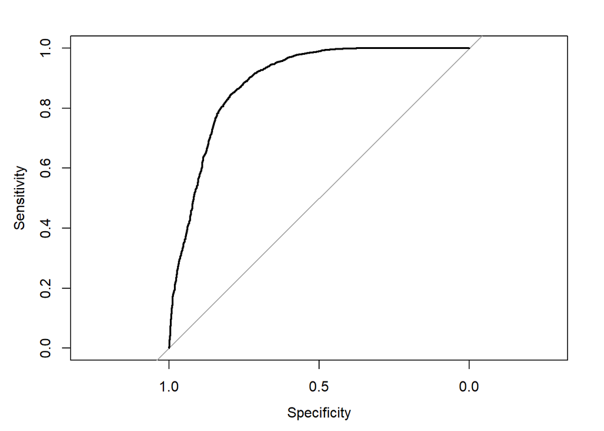

### 7.4.3 McFadden

McFadden is another evaluation tool we can use on logit regressions. This is part of what is called pseudo-R-squared values for evaluation tests. We can calculate the value directly from its definition if we so choose to.

```
## 'log Lik.' 0.41736 (df=13)
```

Or we can use other libraries. The `pscl` (Political Science Computational Lab) library has the function `pR2()` (pseudo-$R^2$) which will do the trick.

```
## fitting null model for pseudo-r2
```

```
##           llh       llhNull            G2      McFadden          r2ML
## -2753.6284428 -4726.1228998  3944.9889140     0.4173600     0.3375964
##          r2CU
##     0.5382092
```

With the McFadden value of 0.41736, which is analogous to the coefficient of determination $R^2$, only about 42% of the variation in y is explained by the explanatory variables in the model.

### 7.4.4 Hosmer and Lemeshow Test

The Hosmer and Lemeshow Goodness of Fit test can be used to evaluate logistic regression fit.

```
##
##  Hosmer and Lemeshow goodness of fit (GOF) test
##
## data:  loans_logit_credit$credit.policy, fitted(logit_credit_model)
## X-squared = 9578, df = 8, p-value < 2.2e-16
```

# 8 Logistic Regression for Not Fully Paid

## 8.1 Effects on Not Fully Paind by Purpose

To study the effects on `not.fully.paid` by the factor `purpose` (`not.fully.paid` and `purpose` are both categorical variables), we can create two-way contingency table of the outcome and predictors, and make sure there are no cells of zero frequencies.

|  | all_other | credit_card | debt_consolidation | educational | home_improvement | major_purchase | small_business |
| --- | --- | --- | --- | --- | --- | --- | --- |
| FALSE | 1944 | 1116 | 3354 | 274 | 522 | 388 | 447 |
| TRUE | 387 | 146 | 603 | 69 | 107 | 49 | 172 |

## 8.2 Feature Selection

This helps us rank the dependent variables in the order of their statistical significance while predicting `not.fully.paid`. Since, all the variables are available at the time of deciding if the loan can be paid back or not all the variables are applied whilebuilding the final model.

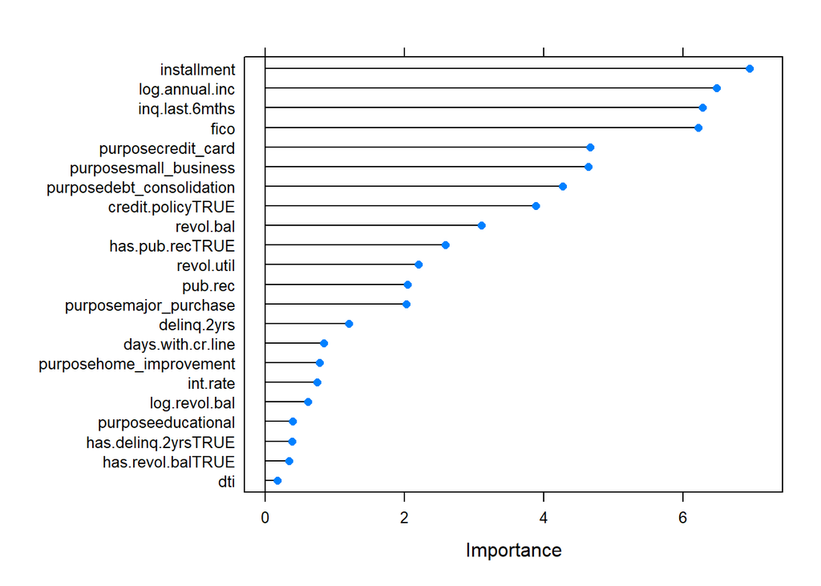

## 8.3 Logistic Regression Model

We can see the summary of the logit model here:

Logistic Regression :

|  | Estimate | Std. Error | z value | Pr(>\|z\|) |
| --- | --- | --- | --- | --- |
| (Intercept) | 8.5476 | 1.2977 | 6.5866 | 0.0000 |
| credit.policyTRUE | -0.3289 | 0.0847 | -3.8812 | 0.0001 |
| purposecredit_card | -0.5124 | 0.1099 | -4.6621 | 0.0000 |
| purposedebt_consolidation | -0.3336 | 0.0781 | -4.2689 | 0.0000 |
| purposeeducational | 0.0606 | 0.1522 | 0.3984 | 0.6904 |
| purposehome_improvement | 0.0991 | 0.1266 | 0.7828 | 0.4337 |
| purposemajor_purchase | -0.3369 | 0.1664 | -2.0248 | 0.0429 |
| purposesmall_business | 0.5445 | 0.1173 | 4.6419 | 0.0000 |
| int.rate | 1.2989 | 1.7448 | 0.7445 | 0.4566 |
| installment | 0.0012 | 0.0002 | 6.9552 | 0.0000 |
| log.annual.inc | -0.3943 | 0.0609 | -6.4791 | 0.0000 |
| dti | 0.0008 | 0.0047 | 0.1743 | 0.8616 |
| fico | -0.0089 | 0.0014 | -6.2163 | 0.0000 |
| days.with.cr.line | 0.0000 | 0.0000 | 0.8422 | 0.3997 |
| revol.bal | 0.0000 | 0.0000 | 3.1008 | 0.0019 |
| revol.util | 0.0032 | 0.0014 | 2.2034 | 0.0276 |
| inq.last.6mths | 0.0866 | 0.0138 | 6.2747 | 0.0000 |
| delinq.2yrs | -0.1172 | 0.0979 | -1.1974 | 0.2312 |
| pub.rec | -1.4663 | 0.7163 | -2.0471 | 0.0406 |
| has.delinq.2yrsTRUE | 0.0612 | 0.1603 | 0.3821 | 0.7024 |
| has.pub.recTRUE | 1.9091 | 0.7378 | 2.5874 | 0.0097 |
| log.revol.bal | -0.0191 | 0.0310 | -0.6171 | 0.5372 |
| has.revol.balTRUE | -0.0950 | 0.2791 | -0.3403 | 0.7337 |

Before moving on, let us look at the model object `logit_nfp_model` a little deeper. The fitted values can be found from `logit_nfp_model$fitted.values`. And the first fitted value is 0.1292253. This is the probability of being not.fully.paid for data point #1. Compare to the value from `predict(logit_nfp_model)` to be -1.9078255.

The `predict()` function gives us the logit value. You can exponentiate to get the odds ratio p/q as 0.1484027. And finally, we can find p from p/q, and indeed it is confirmed to be 0.1292253.

The easier way to get that is simply use `predict(logit_nfp_model, type = c("response"))[1]` = 0.1292253. The `predict()` function will also allow you to find model prediction with unseen/untrained data points where `fitted.values` do not give.

### 8.3.1 Confidence Intervals

We can easily determine the confidence intervals of each coefficient with these two slightly different ways:

CIs using profiled log-likelihood

|  | 2.5 % | 97.5 % |
| --- | --- | --- |
| (Intercept) | 6.0106 | 11.0984 |
| credit.policyTRUE | -0.4942 | -0.1620 |
| purposecredit_card | -0.7301 | -0.2990 |
| purposedebt_consolidation | -0.4864 | -0.1800 |
| purposeeducational | -0.2436 | 0.3538 |
| purposehome_improvement | -0.1523 | 0.3441 |
| purposemajor_purchase | -0.6731 | -0.0196 |
| purposesmall_business | 0.3133 | 0.7733 |
| int.rate | -2.1291 | 4.7118 |
| installment | 0.0009 | 0.0016 |
| log.annual.inc | -0.5139 | -0.2753 |
| dti | -0.0084 | 0.0101 |
| fico | -0.0117 | -0.0061 |
| days.with.cr.line | 0.0000 | 0.0000 |
| revol.bal | 0.0000 | 0.0000 |
| revol.util | 0.0003 | 0.0060 |
| inq.last.6mths | 0.0597 | 0.1139 |
| delinq.2yrs | -0.3257 | 0.0595 |
| pub.rec | -3.2789 | -0.3499 |
| has.delinq.2yrsTRUE | -0.2447 | 0.3849 |
| has.pub.recTRUE | 0.7324 | 3.7485 |
| log.revol.bal | -0.0794 | 0.0421 |
| has.revol.balTRUE | -0.6438 | 0.4507 |

CIs using standard errors

|  | 2.5 % | 97.5 % |
| --- | --- | --- |
| (Intercept) | 6.0041 | 11.0910 |
| credit.policyTRUE | -0.4949 | -0.1628 |
| purposecredit_card | -0.7278 | -0.2970 |
| purposedebt_consolidation | -0.4867 | -0.1804 |
| purposeeducational | -0.2377 | 0.3589 |
| purposehome_improvement | -0.1490 | 0.3471 |
| purposemajor_purchase | -0.6630 | -0.0108 |
| purposesmall_business | 0.3146 | 0.7744 |
| int.rate | -2.1208 | 4.7187 |
| installment | 0.0009 | 0.0016 |
| log.annual.inc | -0.5136 | -0.2750 |
| dti | -0.0084 | 0.0101 |
| fico | -0.0117 | -0.0061 |
| days.with.cr.line | 0.0000 | 0.0000 |
| revol.bal | 0.0000 | 0.0000 |
| revol.util | 0.0003 | 0.0060 |
| inq.last.6mths | 0.0595 | 0.1136 |
| delinq.2yrs | -0.3091 | 0.0747 |
| pub.rec | -2.8702 | -0.0624 |
| has.delinq.2yrsTRUE | -0.2529 | 0.3753 |
| has.pub.recTRUE | 0.4629 | 3.3552 |
| log.revol.bal | -0.0798 | 0.0416 |
| has.revol.balTRUE | -0.6419 | 0.4520 |

## 8.4 Model evaluation

### 8.4.1 Confusion matrix

Confusion matrix from Logit Model

|  | Predicted FALSE | Predicted TRUE | Total |
| --- | --- | --- | --- |
| Actual FALSE | 7997 | 48 | 8045 |
| Actual TRUE | 1480 | 53 | 1533 |
| Total | 9477 | 101 | 9578 |

### 8.4.2 ROC and AUC

Receiver-Operator-Characteristic (ROC) curve and Area-Under-Curve (AUC) measures the true positive rate (or sensitivity) against the false positive rate (or specificity). The area-under-curve is always between 0.5 and 1. Values higher than 0.8 is considered good model fit.

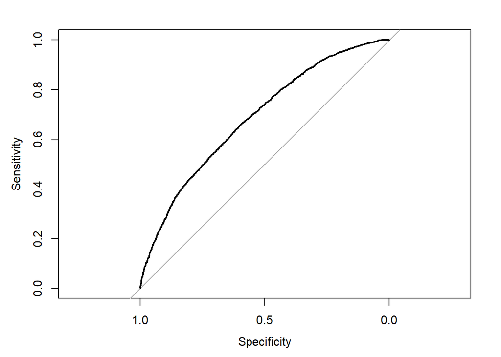

We have here the area-under-curve of 0.6858354, which is less than 0.8. This test also agrees with the Hosmer and Lemeshow test that the model is not considered a good fit.

### 8.4.3 McFadden

McFadden is another evaluation tool we can use on logit regressions. This is part of what is called pseudo-R-squared values for evaluation tests. We can calculate the value directly from its definition if we so choose to.

```
## 'log Lik.' 0.06978116 (df=23)
```

Or we can use other libraries. The `pscl` (Political Science Computational Lab) library has the function `pR2()` (pseudo-$R^2$) which will do the trick.

```
## fitting null model for pseudo-r2
```

```
##           llh       llhNull            G2      McFadden          r2ML
## -3.918101e+03 -4.212020e+03  5.878393e+02  6.978116e-02  5.952848e-02
##          r2CU
##  1.017550e-01
```

### 8.4.4 Hosmer and Lemeshow test

The Hosmer and Lemeshow Goodness of Fit test can be used to evaluate logistic regression fit.

```
##
##  Hosmer and Lemeshow goodness of fit (GOF) test
##
## data:  loans_logit_nfp$not.fully.paid, fitted(logit_nfp_model)
## X-squared = 9578, df = 8, p-value < 2.2e-16
```

# 9 Classification Tree for Credit Policy

## 9.1 Preparing and Building the Tree

For this variable we are interested in the loans where the value is `FALSE`. That is, loans that do not meet the credit underwriting criteria, and therefore are more at risk of defaulting. These loans are in the minority. We will rename the `FALSE` values to `Fail`, indicating that the loan fails to meet the underwriting criteria, and rename the `TRUE` values to `Meets`, indicating that the loan meets the underwriting criteria.

```
##
## Classification tree:
## rpart(formula = credit.policy ~ purpose + int.rate + installment +
##     log.annual.inc + dti + fico + revol.util + inq.last.6mths +
##     delinq.2yrs + pub.rec + not.fully.paid + has.delinq.2yrs +
##     has.pub.rec, data = loans_tree, method = "class", control = list(maxdepth = 4),
##     cp = 0.01)
##
## Variables actually used in tree construction:
## [1] dti            fico           inq.last.6mths
##
## Root node error: 1868/9578 = 0.19503
##
## n= 9578
##
##         CP nsplit rel error  xerror     xstd
## 1 0.484475      0   1.00000 1.00000 0.020759
## 2 0.187366      1   0.51552 0.51552 0.015755
## 3 0.076017      2   0.32816 0.32816 0.012823
## 4 0.042827      3   0.25214 0.25214 0.011329
## 5 0.010000      4   0.20931 0.20985 0.010380
```

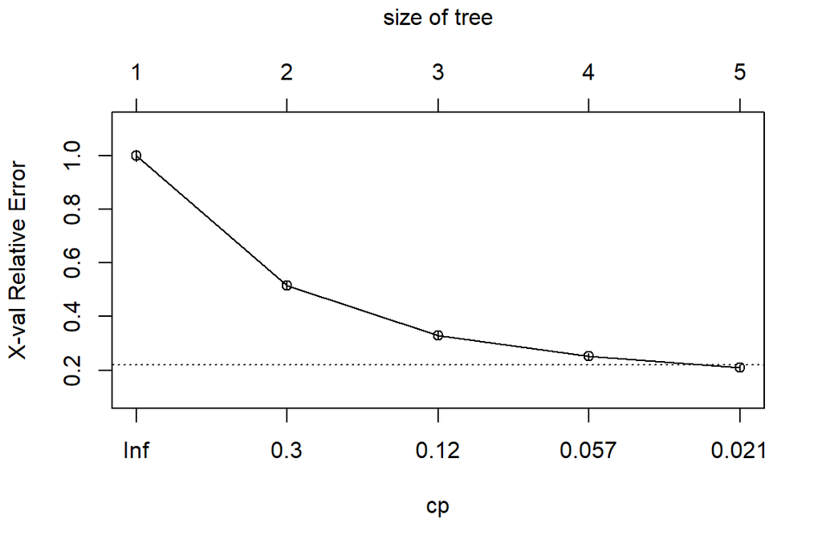

Building the classification tree, we can see that `fico`, `inq.last.6mths`, and `dti` were used in the tree construction and the tree was split 4 times.

## 9.2 Visualizing the Tree

We can better visualize the tree by plotting it out. We can see the `inq.last.6mths` threshold of greater than or equal to four, as well as the two thresholds of 740 and 660 for `FICO` scores. It details that of our 9578 loan sample, there are 1868 loans that failed to meet the `credit.policy` and 7710 that did.

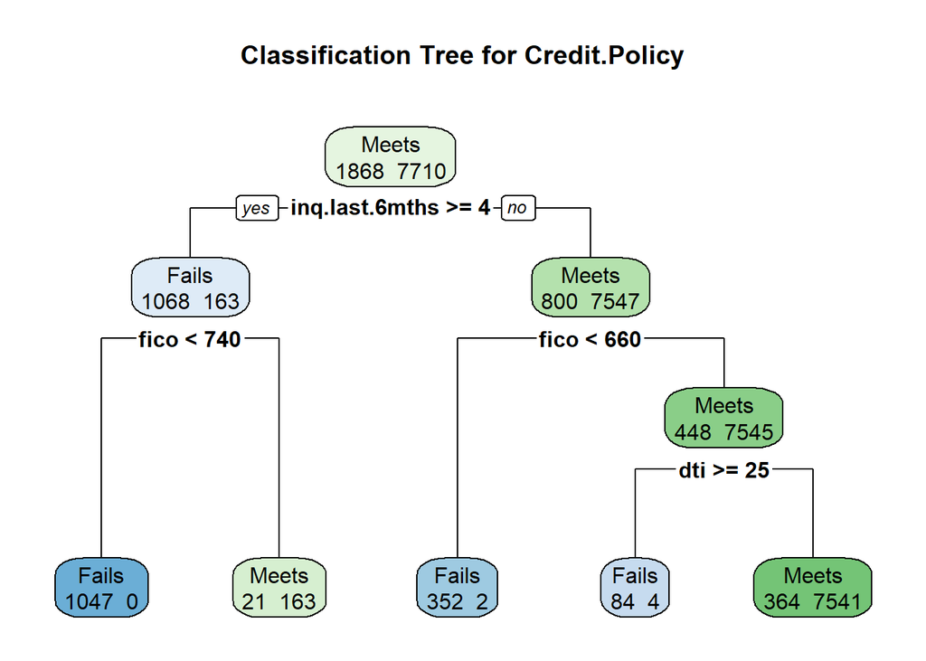

Of all of the loans, 1231 had greater than or equal to four `inq.last.6mths`. Of those 1231:

- 1047 had a `FICO` lower than 740 and failed to meet the `credit.policy`
- 21 had a `FICO` score 740 or higher and failed to meet the `credit.policy`
- 163 had a `FICO` score 740 or higher and met the `credit.policy`

This indicates that applicants will likely need a `FICO` score of 740 or higher if they have greater than or equal to four `inq.last.6mths` in order to anticipate meeting the `credit.policy`.

Conversely, of all of the loans, 8347 had less than four `inq.last.6mths`. Of those 8347:

- 352 had a `FICO` lower than 660 and failed to meet the `credit.policy`
- 2 had a `FICO` lower than 660 but still managed to meet the `credit.policy`
- 448 had a `FICO` score 660 or higher and failed to meet the `credit.policy`
- 7545 had a `FICO` score 660 or higher and met the `credit.policy`

This indicates that applicants will likely need a `FICO` score of only 660 or higher if they have less than four `inq.last.6mths` in order to anticipate meeting the `credit.policy`. We do not consider the threshold for `dti` to be that meaningful because the value of 25 is very high and not representative of most of the loan applicants.

Overall, we can see that less `inq.last.6mths` aligns with lower `FICO` score requirements for the `credit.policy`. Generally, if applicants have equal to or more than four `inq.last.6mths`, then they will likely need a `FICO` score of 740 or higher to meet the `credit.policy`. On the other hand, if applicants have less than four `inq.last.6mths`, then they will likely only need a `FICO` score of 660 or higher to meet the `credit.policy`. If applicants have a `FICO` score lower than 660, then they are unlikely to meet the `credit.policy`, regardless.

## 9.3 Confusion Matrix

To better understand how our model performs we can construct a confusion matrix of the results. The `Fails` values will function as the positive cases for the confusion matrix we put together based on the results of the classification tree model.

```
## [1] "Overall: "
```

```
##       Accuracy          Kappa  AccuracyLower  AccuracyUpper   AccuracyNull
##   9.591773e-01   8.591600e-01   9.550201e-01   9.630522e-01   8.049697e-01
## AccuracyPValue  McnemarPValue
##   0.000000e+00   1.848233e-81
```

Let’s take a closer look and put together tables to visualize the confusion matrix as well some statistics on it.

| Actual | Prediction - Fails | Prediction - Meets |
| --- | --- | --- |
| Fails | 1483 | 385 |
| Meets | 6 | 7704 |

| Statistic | Percentage |
| --- | --- |
| Sensitivity | 79.4% |
| Specificity | 99.9% |
| Pos Pred Value | 99.6% |
| Neg Pred Value | 95.2% |
| Precision | 99.6% |
| Recall | 79.4% |
| F1 | 88.4% |
| Prevalence | 19.5% |
| Detection Rate | 15.5% |
| Detection Prevalence | 15.5% |
| Balanced Accuracy | 89.7% |

The high kappa value of .859 suggests there is a high degree of agreement between the predictions and the actual values. Based on this, we would evaluate this classifier as almost perfect agreement.

The sensitivity and specificity values indicate the test can fairly reliably detect loans that meet and fail to meet the credit policy. The high precision indicates the tree is very good identifying true positives, in that 99.6% of its predicted fails were right.

## 9.4 ROC Curve

Another way that we can evaluate the performance of the model is to look at the ROC curve and the area under the curve (AUC).

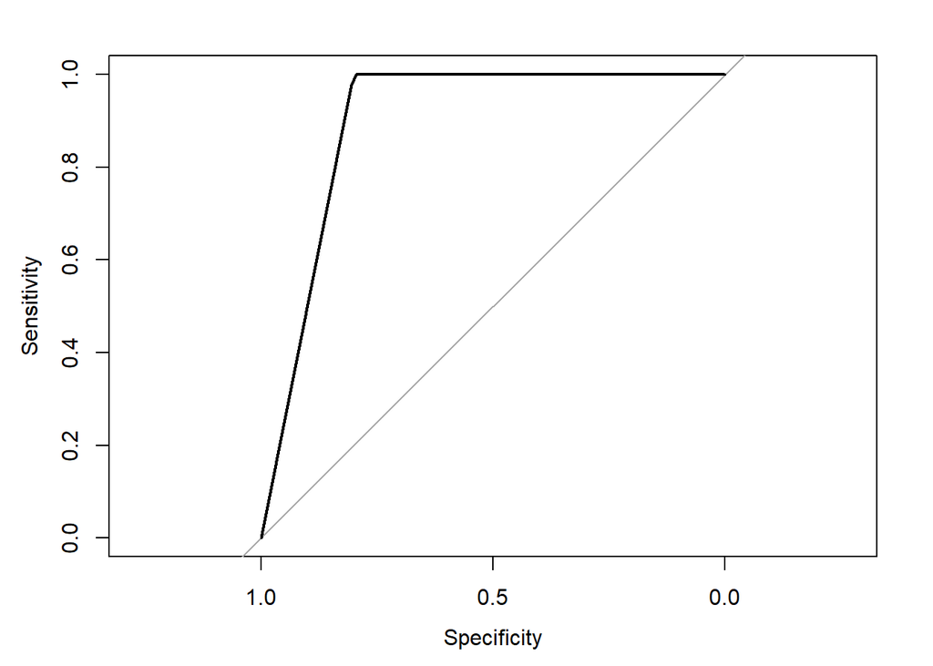

The AUC of the ROC is 0.9, which is greater than the 0.8 threshold, so we would consider this to be a good indicator/model. We can conclude that this is overall an effective model for determining if a loan will meet the credit underwriting policy set by LendingClub.

# 10 Classification Tree for Not Fully Paid

## 10.1 Preparing and Building the Tree

Similar to what we did for, `credit.policy`, was also did to `not.fully.paid` and treated it as a 2-level factor for the tree model.

In this case, we are interested in the loans where the value is `TRUE`. That is, loans that were not fully paid, which are in the minority. We will rename the `TRUE` values to `Unpaid`, indicating they failed to be fully paid, and rename the `FALSE` values to `Paid`, indicating they were paid.

Our initial classification tree for `not.fully.paid` did not choose any variables and had only a single trunk node, a kappa value of 0, and a ROC curve that fit directly on top of the random classifier line. We interpreted this as a strong indicator that a classification tree would not be useful for `not.fully.paid`.

To confirm, we overrode the default complexity parameter in the rpart function and set it from .01 to .001.

```
##
## Classification tree:
## rpart(formula = not.fully.paid ~ purpose + int.rate + installment +
##     log.annual.inc + dti + fico + days.with.cr.line + revol.bal +
##     revol.util + inq.last.6mths + delinq.2yrs + pub.rec + credit.policy +
##     has.delinq.2yrs + has.pub.rec + log.revol.bal + has.revol.bal,
##     data = loans_tree_nfp, method = "class", control = list(maxdepth = 4),
##     cp = 0.001)
##
## Variables actually used in tree construction:
## [1] credit.policy  inq.last.6mths int.rate       purpose
##
## Root node error: 1533/9578 = 0.16005
##
## n= 9578
##
##          CP nsplit rel error xerror     xstd
## 1 0.0014677      0   1.00000 1.0000 0.023407
## 2 0.0010000      4   0.99413 1.0052 0.023457
```

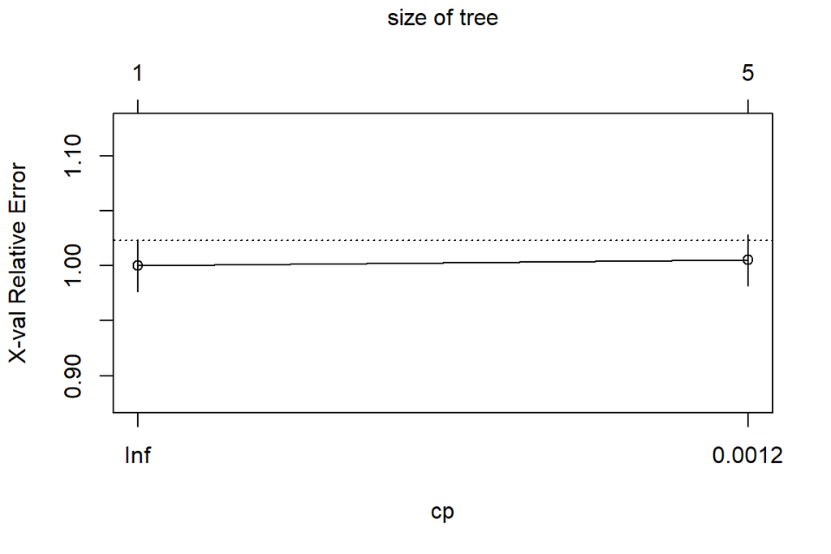

This led to the classification tree using the variables `credit.policy`, `inq.last.6mths`, `int.rate`, and `purpose`.

## 10.2 Visualizing the Tree

We can better visualize this tree by plotting it out.

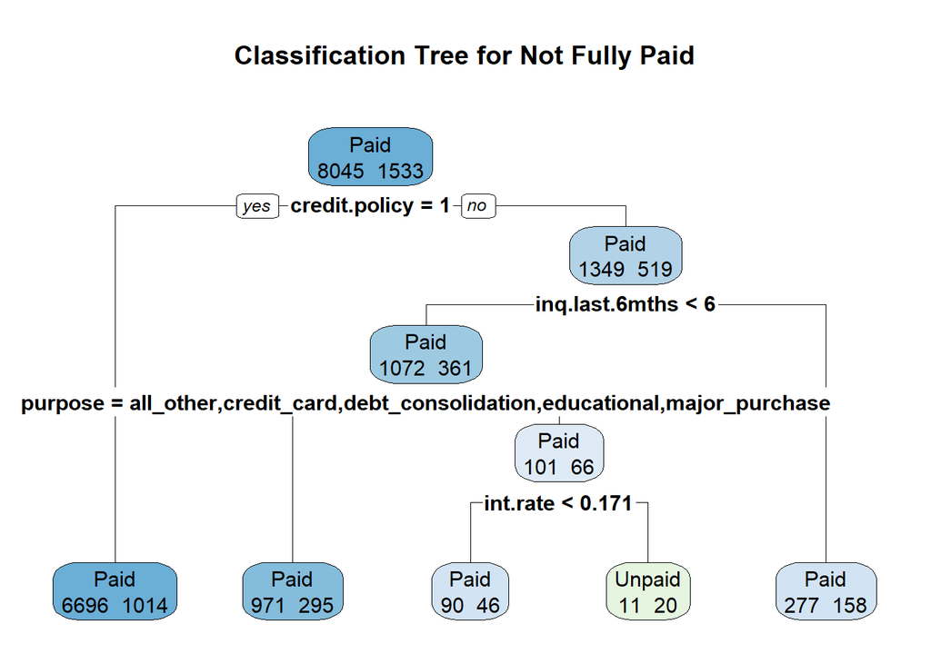

We can see that the tree is not vary useful. The leaf nodes do not come close to zero’ing out and are not very segregated. Overall, we can only infer from the tree that most loans that met the credit policy ended up paying the loan, and that a high number of `inq.last.6mths` and/or a high `int.rate` are yellow flags that point to a loan possibly not being fully paid, all of which are what we would expect for any general loan dataset.

## 10.3 Confusion Matrix

```
## [1] "Overall: "
```

```
##       Accuracy          Kappa  AccuracyLower  AccuracyUpper   AccuracyNull
##   8.408854e-01   1.935338e-02   8.334043e-01   8.481585e-01   8.399457e-01
## AccuracyPValue  McnemarPValue
##   4.075345e-01  1.976263e-323
```

Let’s put together tables to visualize the confusion matrix.

| Actual | Prediction - Paid | Prediction - Unpaid |
| --- | --- | --- |
| Paid | 8034 | 11 |
| Unpaid | 1513 | 20 |

| Statistic | Percentage |
| --- | --- |
| Sensitivity | 99.9% |
| Specificity | 1.3% |
| Pos Pred Value | 84.2% |
| Neg Pred Value | 64.5% |
| Precision | 84.2% |
| Recall | 99.9% |
| F1 | 91.3% |
| Prevalence | 84% |
| Detection Rate | 83.9% |
| Detection Prevalence | 99.7% |
| Balanced Accuracy | 50.6% |

We immediately see the extremely low specificity value, which indicates the tree is poor at detecting those loans that went unpaid.

Based on the Kappa statistic of 0.02 we would evaluate this classifier as only slight agreement, which confirms our initial suspicion that the classification tree for `not.fully.paid` would not be useful.

## 10.4 ROC Curve

Another way that we can evaluate the performance of the model is to look at the ROC curve and the area under the curve (AUC).

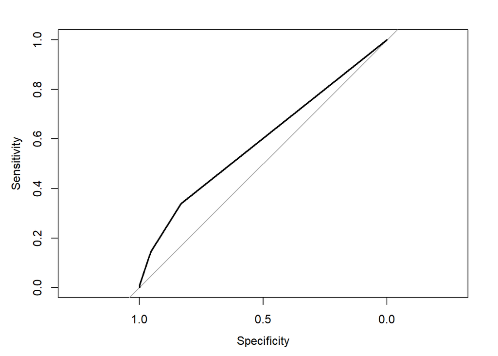

The AUC is 0.59, which is much less than the preferred 0.8 threshold, so we would consider this to be a poor model. This, with some of those other poor statistics, we can confidently conclude that this is overall a poor model for determining if a loan will default.

# 11 Conclusion

Overall, most of our models did not perform well. However, the logistic regression and classification tree models for `credit.policy` worked very well.

## 11.1 Model Application

In our EDA we looked at loans that meet the credit underwriting criteria vs the borrower not fully paying. Based on the `credit.policy` and `not.fully.paid` variables, we calculated the percentage of borrowers who did not fully pay based on if they met the credit underwriting criteria.

| Meets Credit Policy | Percent Not Fully Paid |
| --- | --- |
| FALSE | 27.8% |
| TRUE | 13.2% |

From this we saw that about 13.2% of borrowers who met the credit underwriting criteria did not fully pay, while for the borrowers who did not meet the credit underwriting criteria about 27.8% did not fully pay.

Since our logistic regression and classification tree models for `credit.policy` worked well, we decided to try the same thing using the predicted `credit.policy` from these models. Let’s start with the decision tree model:

| Meets Predicted Credit Policy | Percent Not Fully Paid |
| --- | --- |
| FALSE | 28.8% |
| TRUE | 13.6% |

Now let’s try the logistic regression model:

| Meets Predicted Credit Policy | Percent Not Fully Paid |
| --- | --- |
| FALSE | 29.8% |
| TRUE | 13.8% |

We can see that the results from using our model predictions are about the same as LendingClub’s actual credit underwriting policy. That is to say, if we decided who should get a loan using our models, for this data our models would perform about as well as LendingClub’s credit underwriting policy in terms of trying to avoid giving loans that will end up defaulting.

## 11.2 Answers to SMART Questions

We can provide some answers to our SMART questions as a result of our analysis and modeling.

1. What variable or variables, if any, have an impact on if the person meets the credit underwriting criteria?

We know from our logistic regression and classification tree models that the `fico` and `inq.last.6mths` variables strongly influence the likelihood of a borrorew meeting the credit underwriting criteria (`credit.policy` of `TRUE`).

2. What variable or variables, if any, have an impact on if the person fully repays the loan?

From our analysis and models we were not able to come to a clear answer on this.

3. Do borrowers who meet the credit underwriting criteria have a lower chance of not fully repaying the loan? If so, how big is the difference?

We know that borrowers who meet the credit underwriting criteria are about half as likely to default as those who do not meet the credit underwriting criteria. When we apply our models’ predictions we get very similar results.

In addition, our analysis led us to further explore the factors related to the interest rate of a loan. We hypothesized that the riskier the loan the higher is the interest rate and subsequent installment payments. This was proven true by out MLR and LASSO regression models as `credit.policy` being `TRUE` is one of the most statistically significant factors when predicting `int.rate`.

## 11.3 Research Benefit

As a result of our work we can conclude that meeting the credit underwriting criteria is very important in reducing the likelihood of not fully repaying the loan. Furthermore, we now understand that `fico`, `log.annual.inc`, `purpose`, and `inq.last.6mths` are key factors in determining if borrowers met LendingClub’s credit underwriting criteria, and therefore were at much lower risk of defaulting.

From this we now have a much better understanding of the risk factors that were present in P2P loans.

[figure not shown]

[^1]: “Peer to Peer (P2P) Lending Market Size, Report 2022-2030.” Peer to Peer (P2P) Lending Market Size, Report 2022-2030, www.precedenceresearch.com/peer-to-peer-lending-market. Accessed 4 Nov. 2022.
[^2]: Peng, R. D., & Matsui, E. (2016). The Art of Data Science: A Guide for anyone who works with data. Skybrude consulting LLC.
[^3]: End to end case study (classification): Lending Club Data. (n.d.). Retrieved November 3, 2022, from https://towardsdatascience.com/end-to-end-case-study-classification-lending-club-data-489f8a1b100a
[^4]: Yiu, T. (2019, June 19). Turning Lending Club’s Worst Loans into Investment Gold. Medium. https://towardsdatascience.com/turning-lending-clubs-worst-loans-into-investment-gold-475ec97f58ee
[^5]: Lending Club Review: How it Works, Requirements and Alternatives. (n.d.). Debt.org. https://www.debt.org/credit/loans/personal/lending-club-review/
[^6]: Project 1: Analysis of Lending Club’s data. (n.d.). Data Science Blog. Retrieved November 3, 2022, from https://nycdatascience.com/blog/student-works/project-1-analysis-of-lending-clubs-data/
[^7]: Ph.D, M. K. (2019, April 9). LendingClub: bias in data? Machine learning and investment strategy. Retrieved November 3, 2022, from Medium website: https://michel-kana.medium.com/lendingclub-bias-in-data-machine-learning-and-investment-strategy-3a3bd1c65f0